# World App Pitch

9/24/2019

## Introduction

This is an R Shiny app presentation. The app use the world map data from ggplot2 package to build a 3D model of Earth. It allow use to choose the color and rotate the earth model in three dimension

## Choose the Palette

There are five available palette to choose from. The slide will show the name and display of the palette.

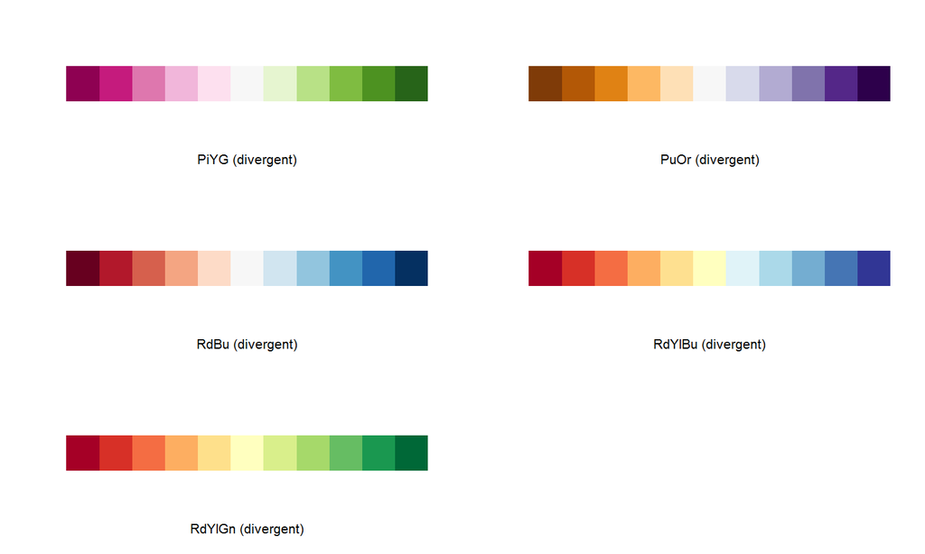

## Rotate in three dimension

The app allow user to choose the value for longitude, latitude and angle. As we know, the earth is a three-axial ellipsoid.

- Longitude will make the model roate around polar axis, the value range from -180 to 180
- Latitude will make the model rotate around one diameter on equator plane, the value range from -90 to 90, at 90 the model will show teh north pole facing and -90 the south pole
- Angle will make the model rotate around another diameter on equator plane, the value range from -180 to 180

## Example

We will show a example of the model given the color palette and three values.  
Palette=Pink Yellow Green, Longtitude=90,Latitude=45,Angle=0

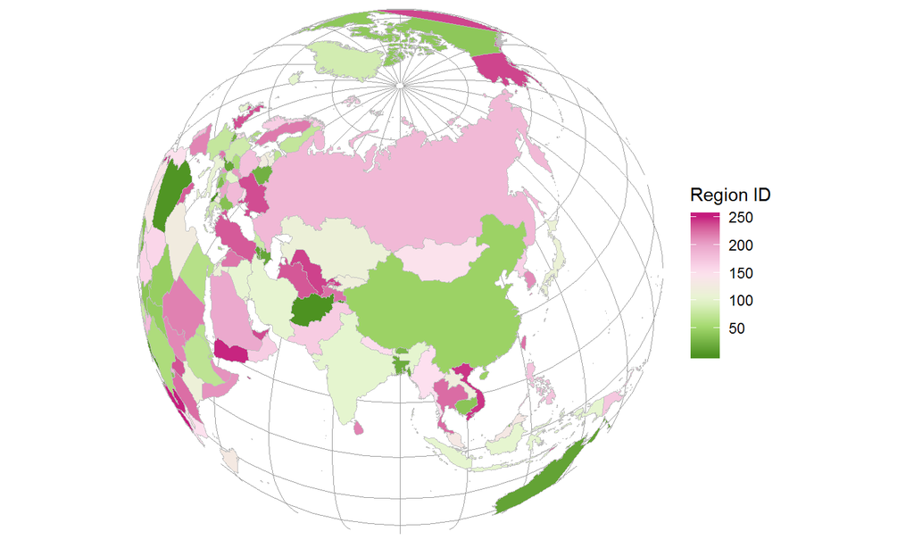